# GLMs Lesson

Samuel Castillo

# Q1 - Why taking the log of the target is a bad idea

The following code illustrates why logging the target is a bad idea. See for yourself what the residuals should look like in a perfect world. Compare this to a transformed target glm.

```r
knitr::opts_chunk$set(warning = FALSE, message = FALSE)

library(tidyverse)
library(purrr)
sim_norm <- function(x) {
  rnorm(1, mean = exp(10 + x), sd = 1)
}

data <- tibble(x = runif(500)) %>%
  mutate(y = x %>% map_dbl(sim_norm))

glm <- glm(y ~ x,
           family = gaussian(link = "log"),
           data = data)

summary(glm)
```

```
Call:
glm(formula = y ~ x, family = gaussian(link = "log"), data = data)

Coefficients:
             Estimate Std. Error t value Pr(>|t|)
(Intercept) 1.000e+01  3.212e-06 3113508   <2e-16 ***
x           1.000e+00  4.567e-06  218944   <2e-16 ***
---
Signif. codes:  0 '***' 0.001 '**' 0.01 '*' 0.05 '.' 0.1 ' ' 1

(Dispersion parameter for gaussian family taken to be 1.10538)

    Null deviance: 5.7514e+10  on 499  degrees of freedom
Residual deviance: 5.5048e+02  on 498  degrees of freedom
AIC: 1473

Number of Fisher Scoring iterations: 2
```

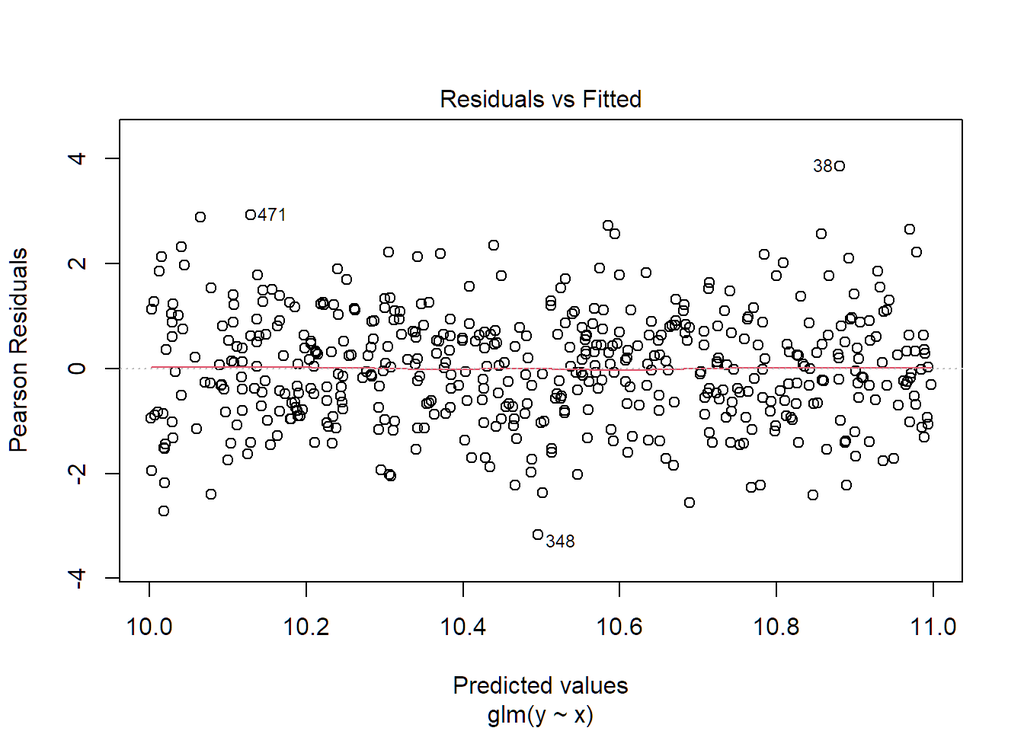

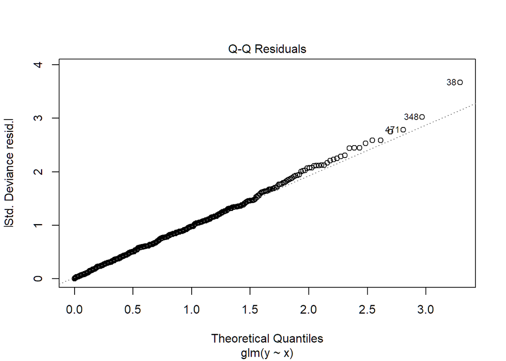

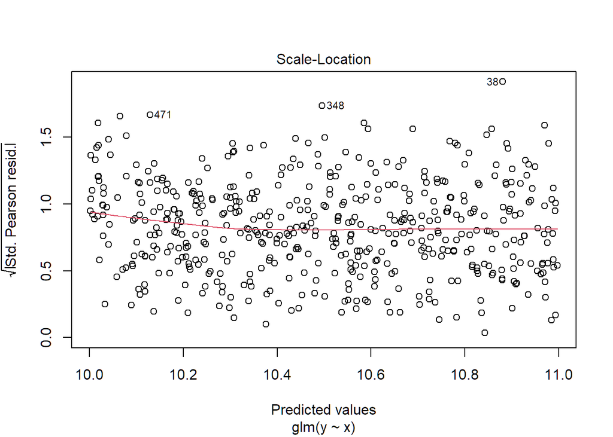

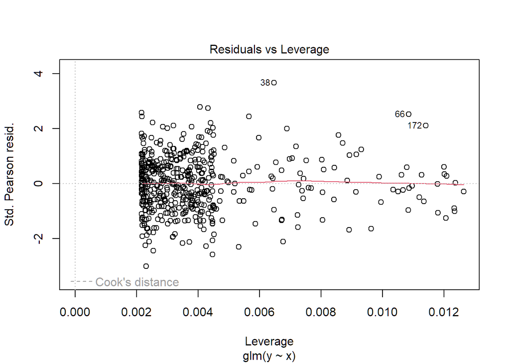

```r
plot(glm)
```

```r
#bad example of applying a log transform to Y - never do this on exam pa!
least_squares <- glm(log(y) ~ x,
                     family = gaussian(link = "identity"),
                     data = data)


#AIC is negative (bad sign)
summary(least_squares)
```

```
Call:
glm(formula = log(y) ~ x, family = gaussian(link = "identity"),
    data = data)

Coefficients:
             Estimate Std. Error t value Pr(>|t|)
(Intercept) 1.000e+01  2.883e-06 3468408   <2e-16 ***
x           1.000e+00  5.023e-06  199098   <2e-16 ***
---
Signif. codes:  0 '***' 0.001 '**' 0.01 '*' 0.05 '.' 0.1 ' ' 1

(Dispersion parameter for gaussian family taken to be 1.025704e-09)

    Null deviance: 4.0659e+01  on 499  degrees of freedom
Residual deviance: 5.1080e-07  on 498  degrees of freedom
AIC: -8926

Number of Fisher Scoring iterations: 2
```

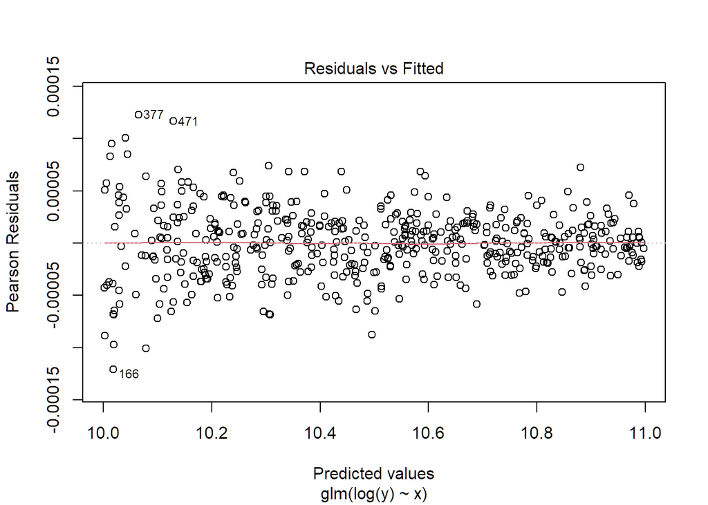

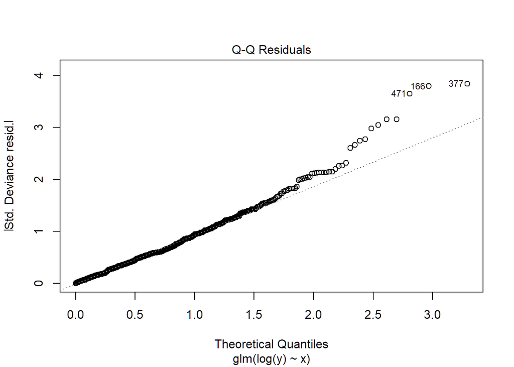

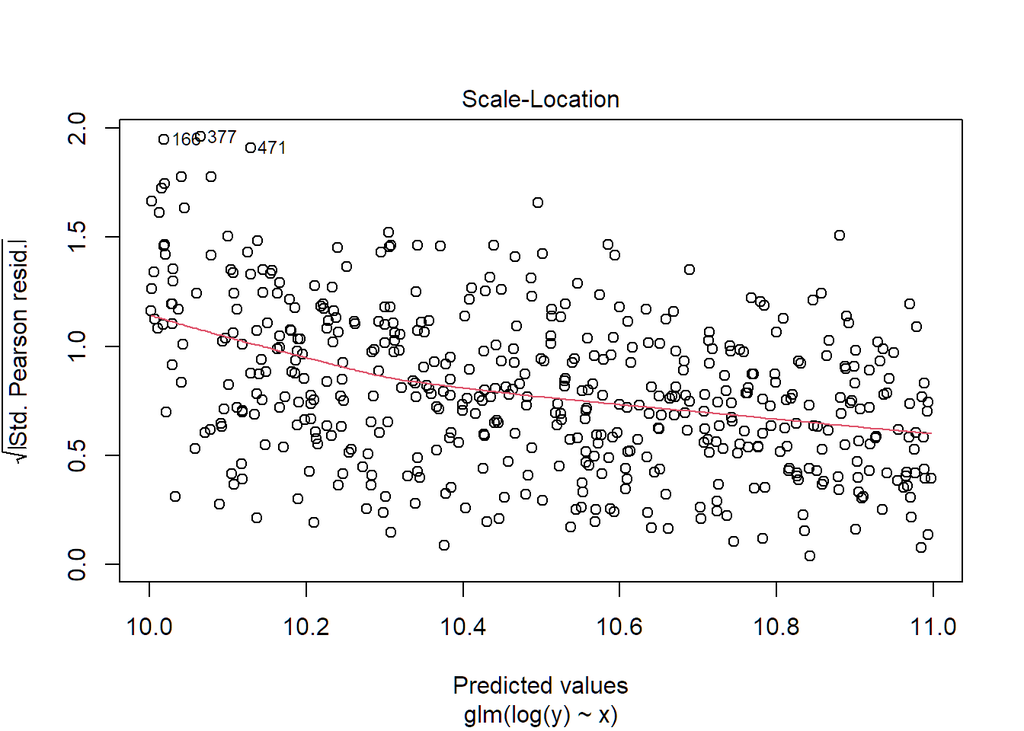

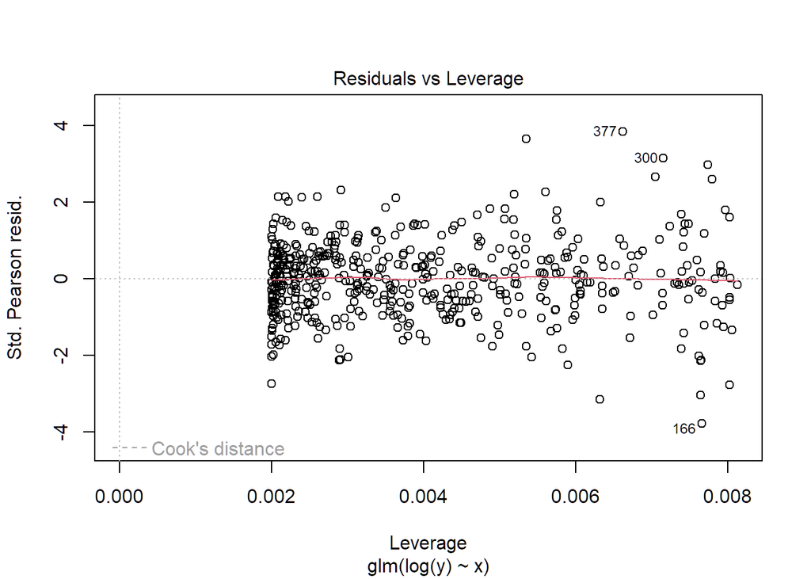

```r
#qq plot has deviations along upper and lower tails
plot(least_squares)
```

# Change the coefficients

```r
sim_norm2 <- function(x1, x2) {
  rnorm(1, mean = exp(10 + 5*x1 + 20*x2), sd = 1)
}

data <- tibble(x1 = runif(500),
               x2 = runif(500)) %>%
  mutate(y = map2_dbl(x1,x2,sim_norm2))


glm <- glm(y ~ x1 + x2, family = gaussian(link = "log"), data = data)

summary(glm)
```

```
Call:
glm(formula = y ~ x1 + x2, family = gaussian(link = "log"), data = data)

Coefficients:
             Estimate Std. Error   t value Pr(>|t|)
(Intercept) 1.000e+01  4.316e-14 2.317e+14   <2e-16 ***
x1          5.000e+00  9.022e-15 5.542e+14   <2e-16 ***
x2          2.000e+01  4.200e-14 4.762e+14   <2e-16 ***
---
Signif. codes:  0 '***' 0.001 '**' 0.01 '*' 0.05 '.' 0.1 ' ' 1

(Dispersion parameter for gaussian family taken to be 2.36635)

    Null deviance: 2.2344e+30  on 499  degrees of freedom
Residual deviance: 1.1761e+03  on 497  degrees of freedom
AIC: 1854.6

Number of Fisher Scoring iterations: 25
```

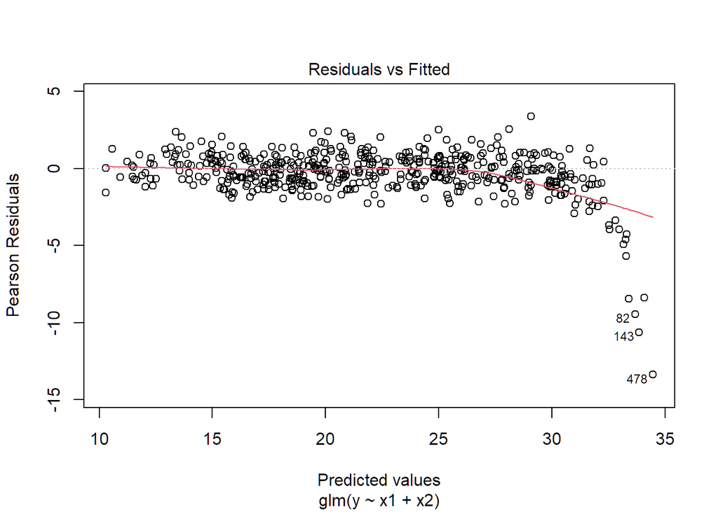

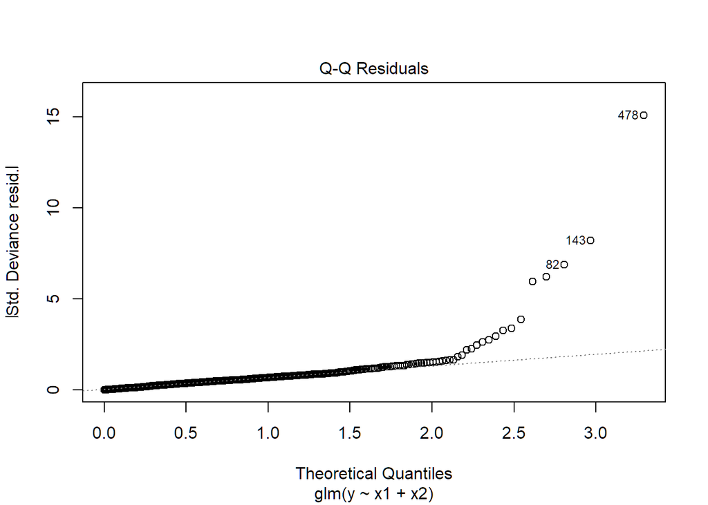

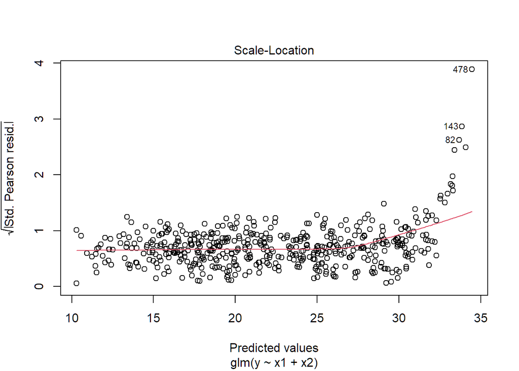

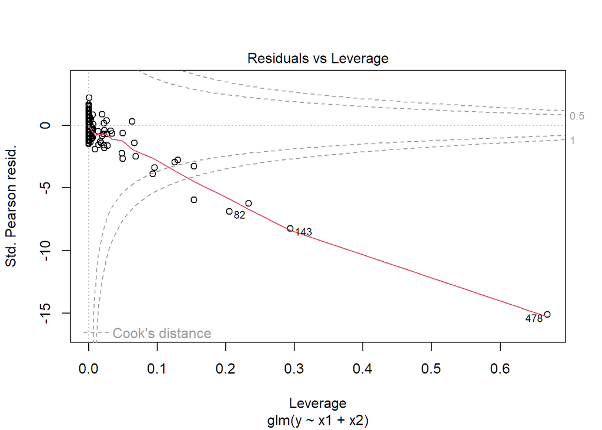

```r
plot(glm)
```

# Interaction Terms

```r
#your code here
```

# Quadratic Terms

```r
#your code here
```

# Answer to Video Question

1. How do ridge regression and the lasso improve on ordinary least squares?

OLS uses maximum likelihood to estimate the coefficients and does not take into consideration the number of variables or the sizes of the coefficients used in the model. Both ridge and the lasso improve the predictive power by taking advantage of the bias variance tradeoff by finding a local minimum in the MSE. The coefficients can be smaller for ridge regression (according to the L2 norm) and there can be fewer coefficients when using the lasso.

2. In what cases would you expect ridge regression to outperform the lasso and vice versa?

### Data #1

n = 10,000 p = 500

There is not enough information to make a decision.

### Data #2

n = 5,000 p = 5

No difference. The lasso’s variable selection will not make much of a difference because there are only 5 predictors.

### Data #3

n = 10,000 p_continuous = 100 p_factor = 2

### Data #4

n = 200 p_continuous = 2 p_factor = 100